[figure not shown]

# Tuning and Transposition

In this notebook, we cover aspects of tuning and transposition following Section 3.1.2.1 and Section 3.1.2.2 of [[Müller, FMP, Springer 2015]](http://www.music-processing.de).

## Tuning

Global frequency deviations may be the result of instruments that are tuned lower or higher than the expected reference pitch $\mathrm{A4}$ with center frequency $440$ Hz. For example, many modern orchestras are using a tuning frequency slightly above $440$ Hz, whereas ensembles that play Baroque music are often tuned lower than $440$ Hz. As an extreme example, consider a recording of a $\mathrm{C}$-major scale, one time played on a piano with standard tuning and one time played on a piano tuned $40$ cents upwards.

[figure not shown]

[interactive chart not shown]

The following figure shows chromagrams assuming the equal-tempered scale with reference tuning $440$ Hz. In the first chromagram the energy is concentrated in the expected chroma bands, where, in the detuned case, the energy of the respective notes is no longer captured by individual chroma bands, but smeared across neighboring bands.

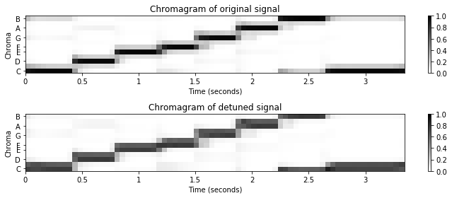

```python
import sys
import os

import numpy as np
from matplotlib import pyplot as plt
import librosa, librosa.display
from scipy.interpolate import interp1d

sys.path.append('..')
from LibFMP.C3 import F_pitch, Gamma as compute_compression

%matplotlib inline

x, Fs = librosa.load(os.path.join('..', 'data', 'C3', 'FMP_C3_F08_C-major-scale.wav'))
x_detune, Fs = librosa.load(os.path.join('..', 'data', 'C3', 'FMP_C3_F08_C-major-scale_40-cents-up.wav'))

N = 4096
H = 1024

C = librosa.feature.chroma_stft(y=x, sr=Fs, tuning=0, norm=2, hop_length=H, n_fft=N)
plt.figure(figsize=(10, 4))
plt.subplot(2, 1, 1)
librosa.display.specshow(C, x_axis='time', y_axis='chroma', cmap='gray_r', hop_length=H)
plt.xlabel('Time (seconds)')
plt.ylabel('Chroma')
plt.clim([0, 1])
plt.colorbar()
plt.title('Chromagram of original signal')

C = librosa.feature.chroma_stft(y=x_detune, sr=Fs, tuning=0, norm=2, hop_length=H, n_fft=N)
plt.subplot(2, 1, 2)
librosa.display.specshow(C, x_axis='time', y_axis='chroma', cmap='gray_r', hop_length=H)
plt.xlabel('Time (seconds)')
plt.ylabel('Chroma')
plt.clim([0, 1])
plt.colorbar()
plt.title('Chromagram of detuned signal')
plt.tight_layout()
```

To compensate for tuning effects, one needs to perform an additional tuning estimation step to adjust the center frequencies of the MIDI pitches as well as the logarithmic partitioning for computing the pitch-based log-frequency spectrogram. The adjustment of the logarithmic partitioning is built into the `librosa` function.

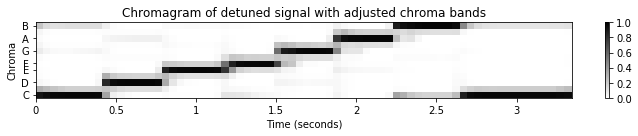

```python
plt.figure(figsize=(10, 2))

tuning = 0.4
C = librosa.feature.chroma_stft(y=x_detune, sr=Fs, tuning=tuning, norm=2, hop_length=H, n_fft=N)
librosa.display.specshow(C, x_axis='time', y_axis='chroma', cmap='gray_r', hop_length=H)
plt.xlabel('Time (seconds)')
plt.ylabel('Chroma')
plt.clim([0, 1])
plt.colorbar()
plt.title('Chromagram of detuned signal with adjusted chroma bands')
plt.tight_layout()
```

## Tuning Estimation

The tuning of musical instruments is usually based on a fixed reference pitch. In Western music, one typically uses the **concert pitch** $\mathrm{A4}$ having a frequency of $440~\mathrm{Hz}$. Therefore, playing a note $\mathrm{A4}$, one can expect dominant frequencies in a neighborhood of $440~\mathrm{Hz}$ (corresponding to the fundamental frequency) and its integer multiples (corresponding to the harmonics). Let $x=(x(0), x(1), ..., x(N-1))$ be a sampled signal (using the sampling rate $F_\mathrm{s}$) of a recorded note $\mathrm{A4}$. Furthermore, let $X = \mathrm{DFT}_N \cdot x$ be its discrete Fourier transform. Then the index $k\in[0:N-1]$ of the Fourier coefficient $X(k)$ corresponds to the physical frequency

\begin{equation} F_\mathrm{coef}(k) := \frac{k\cdot F_\mathrm{s}}{N} \end{equation}

given in Hertz. Then, one may look for the frequency index $k_0$ that yields a maximal magnitude coefficient $|F_\mathrm{coef}(k_0)|$ in a neighborhood of $440~\mathrm{Hz}$ (e.g., plus/minus a semitone). The difference

$$F_\mathrm{coef}(k_0)-440$$

then yields an estimate of the tuning deviation. To obtain a more robust estimate, one may also consider spectral peak positions in suitably defined neighborhoods of the harmonics. Of course, any other note could also be used in a similar fashion to estimate a tuning deviation from the ideal center frequency expressed by the function

$$ F_\mathrm{pitch}(p) = 2^{(p-69)/12} \cdot 440. $$

In general, given an entire music recording, one can not assume that one has a single note being played in isolation. In the following, we consider the scenario where the recorded music is based on the $12$-tone equal-tempered scale, but possibly deviates from the ideal tuning. We assume that this deviation can be expressed by a single parameter $\theta$ given in cents. For example, in our detuned $\mathrm{C}$-major scale used before, we have $\theta=40$ cents. The objective of tuning estimation is then to determine this parameter $\theta$. In the following, we sketch basic procedure.

- Compute the DFT $X\in\mathbb{C}$ of a music recording (or a local section thereof).
- Compute a compressed version of the magnitude DFT to enhance small signal components.
- Convert the frequency axis into a **logarithmic axis** (given in cents) using interpolation techniques. This results in a vector $v\in\mathbb{R}^M$ representing a kind of frequency distribution of the music recording.
- Compute a dictionary of **comb-like template vectors** $w_\theta\in\mathbb{R}^M$ for tuning parameters $\theta\in \Theta$ (given in cents). The set $\Theta$ represents the set of all possible tuning deviations to be considered (e.g. ranging from $-50$ to $+50$ cents). Each template $w_\theta$ encodes the ideal pitch grid using a $12$-tone equal-tempered scale with a reference tuning shifted by $\theta$ cents.
- Finally, we compare $v$ with all $w_\theta$ using a suitable similarity measure (e.g. inner product). The tuning parameter is then defined to be the **similarity-maximizing parameter** $\theta_\mathrm{max}$.

An implementation of this basic procedure can be found in the next code cell. Obviously, there are many ways to improve this basic procedure.

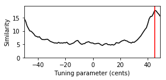

[figure not shown]

```python
def compute_F_coef_log(R, F_min, F_max):
    # R = resolution (cents)
    # F_min = minimum frequency
    # F_max = maximum frequency
    n_bins = np.ceil(1200 * np.log2(F_max / F_min) / R).astype(int)
    F_coef_interpol = 2 ** (np.arange(0, n_bins) * R / 1200) * F_min
    F_coef_cents = np.arange(0, n_bins) * 1200 * np.log2(F_max / F_min) / n_bins
    return F_coef_interpol, F_coef_cents

def compute_pitch_template(size, cent_max, theta=0, R=1):
    template = np.zeros(size)
    pitch_positions = (np.arange(0, cent_max, 100) + theta) // R
    pitch_positions = np.intersect1d(pitch_positions, np.arange(size)).astype(int)
    template[pitch_positions] = 1
    return template

# x, Fs = librosa.load(os.path.join('..', 'data', 'C3', 'FMP_C3_F08_C-major-scale.wav'))
x, Fs = librosa.load(os.path.join('..', 'data', 'C3', 'FMP_C3_F08_C-major-scale_40-cents-up.wav'))
# x, Fs = librosa.load(os.path.join('..', 'data', 'C3', 'FMP_C3_NoteC4_Flute.wav'))
# x, Fs = librosa.load(os.path.join('..', 'data', 'C3', 'FMP_C3_NoteC4_Violin.wav'))
# x, Fs = librosa.load(os.path.join('..', 'data', 'C3', 'FMP_C3_F05.wav'))
#x, Fs = librosa.load(os.path.join('..', 'data', 'C8', 'FMP_C8_F10_Weber_Freischuetz-06_FreiDi-35-40.wav'))
#x, Fs = librosa.load(os.path.join('..', 'data', 'C8', 'FMP_C8_Audio_Bornemark_StopMessingWithMe-Excerpt_SoundCloud_mix.wav'))
#x, Fs = librosa.load(os.path.join('..', 'data', 'C8', 'FMP_C8_Audio_Bornemark_StopMessingWithMe-Excerpt_SoundCloud_vocals.wav'))
#x, Fs = librosa.load(os.path.join('..', 'data', 'C8', 'FMP_C8_Audio_Bornemark_StopMessingWithMe-Excerpt_SoundCloud_accomp.wav'))


# Only use a small section for the tuning estimation
t_min = 0
t_max = len(x)
x_section = x[t_min:t_max]
N = t_max - t_min

# Compression may help to enhance small signal components
Y = np.abs(np.fft.fft(x_section)) / Fs
Y = Y[:N//2+1]
Y = compute_compression(Y, gamma=100)
F_coef = np.arange(N // 2 + 1) * Fs / N

# Convert linearly spaced frequency axis in logarithmic axis (given in cents)
# The minimum frequency F_min corresponds 0 cents.
R = 1                    # Resolution in cents
p_min = 24               # C1, MIDI pitch 24
F_min = F_pitch(p_min)   # 32.70 Hz
p_max = 108              # C8, MIDI pitch 108
F_max = F_pitch(p_max)   # 4186.01 Hz
F_coef_interpol, F_coef_cents  = compute_F_coef_log(R, F_min, F_max)
v = interp1d(F_coef, Y, kind='cubic')(F_coef_interpol)
M = v.size

# Compute templates and compare with spectral vector v
Theta = np.arange(-50, 50, R) # Theta specified in cents
num_Theta = len(Theta)
similarity = np.zeros(num_Theta)
for i in range(num_Theta):
    theta = Theta[i]
    w_theta = compute_pitch_template(size=M, cent_max=F_coef_cents[-1], theta=theta, R=R)
    similarity[i] = np.inner(w_theta, v)

index_max = np.argmax(similarity)
theta_max = Theta[index_max]
v_max = compute_pitch_template(size=M, cent_max=F_coef_cents[-1], theta=theta_max, R=R)

plt.figure(figsize=(4, 2))
plt.plot(Theta, similarity, 'k')
plt.xlim([Theta[0], Theta[-1]])
plt.ylim([0, np.max(similarity) * 1.1])
plt.plot([theta_max, theta_max], [0, np.max(similarity) * 1.1], 'r')
plt.xlabel('Tuning parameter (cents)')
plt.ylabel('Similarity')
plt.tight_layout()

plt.figure(figsize=(15, 4))
plt.plot(F_coef_cents, v, c='k')
plt.xlim([F_coef_cents[0], F_coef_cents[-1]])
ylim = np.max(v) * 1.1
plt.ylim([0, ylim])
x_ticks_freq = np.array([0, 1200, 2400, 3600, 4800, 6000, 7200, 8000])
plt.plot(F_coef_cents, v_max * ylim / 3, 'r')
plt.xticks(x_ticks_freq)
plt.xlabel('Frequency (cents)')
plt.title(r'Spectral distribution with optimal pitch grid with $\theta$ = %.1f cents' % theta_max)
plt.tight_layout()
```

## Transposition

Next, we want to discuss a property of chroma features by which one can simulate a **transposition**, a concept used in music to shift a melody or an entire piece of music to another key. Such modifications are often applied to adapt the pitch range of a given piece to a different instrument or singer. Technically speaking, a transposition refers to the process of moving a collection of notes up or down in pitch by a constant interval. For example, shifting the notes of a C-major scale 4 semitones upwards, one obtains the E-major scale.

[interactive chart not shown]

To understand the effect on the chroma level, recall that the twelve chroma values, which we identified with the set $[0:11]$, are cyclically ordered. This motivates the definition of the **cyclic shift operator** $\rho:\mathbb{R}^{12} \to \mathbb{R}^{12}$. Given a chroma vector $x=(x(0),x(1),\ldots,x(10),x(11))^\intercal\in\mathbb{R}^{12}$, we define

\begin{equation} \rho(x):=(x(11),x(0),x(1),\ldots,x(10))^\intercal. \end{equation}

In other words, the chroma band $\mathrm{C}$ in $x$ becomes the chroma band $\mathrm{C}^\sharp$ in $\rho(x)$, the band $\mathrm{C}^\sharp$ becomes $\mathrm{D}$, and so on, and the last band $\mathrm{B}$ becomes $\mathrm{C}$. The cyclic shift operator can be applied successively obtaining $\rho^i:=\rho\circ\rho^{i-1}$ for $i\in\mathbb{N}$, which defines a cyclic shift of $i$ semitones upwards. Obviously, $\rho^{12}(x) = x$, which means that, by cyclically shifting a chroma vector twelve semitones (one octave) upwards, one recovers the original vector. Applying the cyclic shift operator to all frames of a chromagram simultaneously leads to a cyclical shift of the entire chromagram in the vertical direction. This is illustrated by the next example, where the original chromagram of the C-major scale has been shifted four semitones upwards. This results in a chromagram that looks like the one of an E-major scale, a transposition of four semitones.

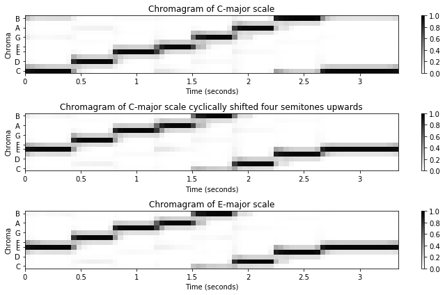

```python
def rho(C, shift=1):
    C_shift = np.roll(C, shift=shift, axis=0)
    return C_shift

x_cmajor, Fs = librosa.load(os.path.join('..', 'data', 'C3', 'FMP_C3_F08_C-major-scale.wav'))
x_emajor, Fs = librosa.load(os.path.join('..', 'data', 'C3', 'FMP_C3_F08_C-major-scale_400-cents-up.wav'))

N = 4096
H = 1024

C = librosa.feature.chroma_stft(y=x_cmajor, sr=Fs, tuning=0, norm=2, hop_length=H, n_fft=N)
plt.figure(figsize=(10, 6))
plt.subplot(3, 1, 1)
librosa.display.specshow(C, x_axis='time', y_axis='chroma', cmap='gray_r', hop_length=H)
plt.xlabel('Time (seconds)')
plt.ylabel('Chroma')
plt.clim([0, 1])
plt.colorbar()
plt.title('Chromagram of C-major scale')

C = librosa.feature.chroma_stft(y=x_cmajor, sr=Fs, tuning=0, norm=2, hop_length=H, n_fft=N)
C_shift = rho(C, shift=4)
plt.subplot(3, 1, 2)
librosa.display.specshow(C_shift, x_axis='time', y_axis='chroma', cmap='gray_r', hop_length=H)
plt.xlabel('Time (seconds)')
plt.ylabel('Chroma')
plt.clim([0, 1])
plt.colorbar()
plt.title('Chromagram of C-major scale cyclically shifted four semitones upwards')

C = librosa.feature.chroma_stft(y=x_emajor, sr=Fs, tuning=0, norm=2, hop_length=H, n_fft=N)
plt.subplot(3, 1, 3)
librosa.display.specshow(C, x_axis='time', y_axis='chroma', cmap='gray_r', hop_length=H)
plt.xlabel('Time (seconds)')
plt.ylabel('Chroma')
plt.clim([0, 1])
plt.colorbar()
plt.title('Chromagram of E-major scale')
plt.tight_layout()
```

**Acknowledgment:** This notebook was created by [Meinard Müller](https://www.audiolabs-erlangen.de/fau/professor/mueller).